# CS 422 - Homework 8

Imaduddin Sheikh

###### Due Date: Tuesday, April 19 2022 11:59:59 PM Chicago Time

### 2. Practicum Problems

### 2.1. K-means clustering

```r
library("factoextra")
library("ggplot2")
library("dplyr")
library("cluster")
setwd("~/Homework 8")
```

```r
txt.to.df <- function(txt.file,out.df) {
  file19.txt.df <- read.csv(file= txt.file,
                           header = FALSE,
                           sep = "",
                           dec = ".",
                           comment.char = "#"

                           )

  write.csv(file19.txt.df, file = out.df)
  file19.txt.df <- read.csv(file= out.df,
                           header = TRUE,
                           sep = ",",
                           dec = ".",
                           comment.char = "#",
                         skip = 4
                           )
  write.csv(file19.txt.df[,1:10], file = out.df,row.names = F)
  file19.txt.df <- read.csv(out.df,row.names = 1)
  row.names(file19.txt.df) <- NULL

  return( file19.txt.df)
}
```

### Part 2.1(a)

```r
file19.df <- txt.to.df(txt.file = "file19.txt", out.df = "file19.csv")
dim(file19.df)
```

```
[1] 66  9
```

```r
file19.df
```

| Name | I | i | C | c | P | p | M | m |
| --- | --- | --- | --- | --- | --- | --- | --- | --- |
| Opossum | 5 | 4 | 1 | 1 | 3 | 3 | 4 | 4 |
| Hairy tail mole | 3 | 3 | 1 | 1 | 4 | 4 | 3 | 3 |
| Common mole | 3 | 2 | 1 | 0 | 3 | 3 | 3 | 3 |
| Star nose mole | 3 | 3 | 1 | 1 | 4 | 4 | 3 | 3 |
| Brown bat | 2 | 3 | 1 | 1 | 3 | 3 | 3 | 3 |
| Silver hair bat | 2 | 3 | 1 | 1 | 2 | 3 | 3 | 3 |
| Pigmy bat | 2 | 3 | 1 | 1 | 2 | 2 | 3 | 3 |
| House bat | 2 | 3 | 1 | 1 | 1 | 2 | 3 | 3 |
| Red bat | 1 | 3 | 1 | 1 | 2 | 2 | 3 | 3 |
| Hoary bat | 1 | 3 | 1 | 1 | 2 | 2 | 3 | 3 |

[output cut: 56 more lines]

```r
summary(file19.df)
```

```
     Name                 I               i               C                c                P               p               M
 Length:66          Min.   :0.000   Min.   :0.000   Min.   :0.0000   Min.   :0.0000   Min.   :0.000   Min.   :0.000   Min.   :0.000
 Class :character   1st Qu.:1.000   1st Qu.:1.000   1st Qu.:0.0000   1st Qu.:0.0000   1st Qu.:2.000   1st Qu.:1.000   1st Qu.:1.000
 Mode  :character   Median :2.000   Median :3.000   Median :1.0000   Median :1.0000   Median :3.000   Median :3.000   Median :3.000
                    Mean   :1.803   Mean   :2.379   Mean   :0.5909   Mean   :0.5455   Mean   :2.561   Mean   :2.424   Mean   :2.455
                    3rd Qu.:3.000   3rd Qu.:3.000   3rd Qu.:1.0000   3rd Qu.:1.0000   3rd Qu.:3.000   3rd Qu.:3.000   3rd Qu.:3.000
                    Max.   :5.000   Max.   :4.000   Max.   :1.0000   Max.   :1.0000   Max.   :4.000   Max.   :4.000   Max.   :8.000
       m
 Min.   :0.000
 1st Qu.:2.000
 Median :3.000
 Mean   :2.636
 3rd Qu.:3.000
 Max.   :8.000
```

```r
apply(file19.df,2,sd)
```

```
     Name         I         i         C         c         P         p         M         m
       NA 1.1925370 1.1604396 0.4954337 0.5017452 1.2169165 1.2656480 1.1659505 1.0173323
```

### Part 2.1(a)(i)

Only the names **Name** feature is to be omitted. For the remaining features, the summary of the data extracted from the *file19.txt* and the standard deviations of the features indicate that they do not need to be omitted.

```r
df <- file19.df[-1]
df
```

| I | i | C | c | P | p | M | m |
| --- | --- | --- | --- | --- | --- | --- | --- |
| 5 | 4 | 1 | 1 | 3 | 3 | 4 | 4 |
| 3 | 3 | 1 | 1 | 4 | 4 | 3 | 3 |
| 3 | 2 | 1 | 0 | 3 | 3 | 3 | 3 |
| 3 | 3 | 1 | 1 | 4 | 4 | 3 | 3 |
| 2 | 3 | 1 | 1 | 3 | 3 | 3 | 3 |
| 2 | 3 | 1 | 1 | 2 | 3 | 3 | 3 |
| 2 | 3 | 1 | 1 | 2 | 2 | 3 | 3 |
| 2 | 3 | 1 | 1 | 1 | 2 | 3 | 3 |
| 1 | 3 | 1 | 1 | 2 | 2 | 3 | 3 |
| 1 | 3 | 1 | 1 | 2 | 2 | 3 | 3 |

[output cut: 56 more lines]

### Part 2.1(a)(ii)

The mean of the data is not equal to zero for each feature. Hence, the data is not standardized.

```r
scaled.df <- scale(df)
```

```r
summary(scaled.df)
```

```
       I                 i                 C                 c                 P                 p                 M
 Min.   :-1.5119   Min.   :-2.0499   Min.   :-1.1927   Min.   :-1.0871   Min.   :-2.1042   Min.   :-1.9154   Min.   :-2.1052
 1st Qu.:-0.6734   1st Qu.:-1.1882   1st Qu.:-1.1927   1st Qu.:-1.0871   1st Qu.:-0.4607   1st Qu.:-1.1253   1st Qu.:-1.2475
 Median : 0.1652   Median : 0.5353   Median : 0.8257   Median : 0.9059   Median : 0.3611   Median : 0.4549   Median : 0.4678
 Mean   : 0.0000   Mean   : 0.0000   Mean   : 0.0000   Mean   : 0.0000   Mean   : 0.0000   Mean   : 0.0000   Mean   : 0.0000
 3rd Qu.: 1.0037   3rd Qu.: 0.5353   3rd Qu.: 0.8257   3rd Qu.: 0.9059   3rd Qu.: 0.3611   3rd Qu.: 0.4549   3rd Qu.: 0.4678
 Max.   : 2.6808   Max.   : 1.3971   Max.   : 0.8257   Max.   : 0.9059   Max.   : 1.1828   Max.   : 1.2450   Max.   : 4.7562
       m
 Min.   :-2.5914
 1st Qu.:-0.6255
 Median : 0.3574
 Mean   : 0.0000
 3rd Qu.: 0.3574
 Max.   : 5.2723
```

### Part 2.1(a)(iii)

The function implemented created at the start of the R notebook takes care of the cleaning and the creation of the cleaned data set. The function is called **txt.to.df**, and the cleaned data set is titled **file19.csv**.

### Part 2.1(b)

### Part 2.1(b)(i)

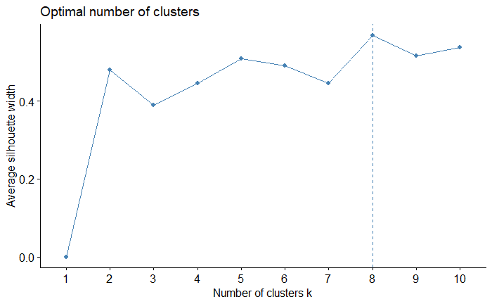

```r
fviz_nbclust(scaled.df, kmeans, method="silhouette")
```

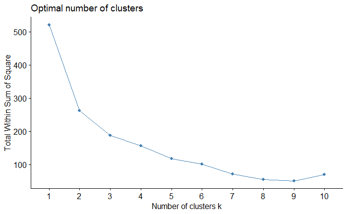

```r
fviz_nbclust(scaled.df, kmeans, method="wss")
```

After taking both the WSS and Silhouette graphs into account, I feel that the 8 would be an ideal number for clusters. The average silhouette value is highest and the total WSS the second-lowest(very close to the minimum) when k = 8.

### Part 2.1(b)(ii)

```r
k <- kmeans(scaled.df, centers=8, nstart=25)
```

```r
k
```

```
K-means clustering with 8 clusters of sizes 1, 14, 10, 9, 4, 8, 15, 5

Cluster means:
            I          i          C          c          P           p          M          m
1 -1.51192817 -2.0499024 -1.1927107 -1.0871146 -2.1041756 -1.91541603  4.7561664  5.2722560
2 -0.55358715 -1.1881600 -1.1927107 -1.0871146 -0.7541593 -1.01243419  0.4678196  0.3574411
3  1.00371702  0.5353248  0.8257228  0.7066245  1.0184708  1.08699860  0.2105188  0.2591448
4 -1.51192817  1.3970672 -0.7441700 -1.0871146  0.3610716  0.45491131  0.4678196  0.3574411
5  0.37480572 -0.9727244  0.8257228  0.9059288  0.9773834  1.04749314 -1.4619364 -1.8542256
6 -0.04446848  0.5353248  0.8257228  0.9059288 -0.3579589  0.05985675  0.4678196  0.3574411
7  1.00371702  0.4204258  0.8257228  0.9059288  0.5802046  0.40223737 -1.1903411 -0.8876454
8 -0.67337977 -1.1881600 -1.1927107 -1.0871146 -2.1041756 -1.91541603  0.4678196  0.3574411

Clustering vector:
 [1] 3 3 3 3 6 6 6 6 6 6 6 1 2 2 2 2 2 2 2 2 2 2 2 2 8 8 8 8 8 2 2 3 3 3 3 3 3 7 7 7 7 7 7 7 7 7 7 7 7 7 7 5 5 5 7 5 6 4 4 4 4 4 4 4 4
[66] 4

Within cluster sum of squares by cluster:
[1] 0.000000e+00 5.796663e+00 1.858275e+01 6.337449e+00 6.226867e+00 4.244696e+00 1.111705e+01 2.465190e-31
 (between_SS / total_SS =  89.9 %)

Available components:

[1] "cluster"      "centers"      "totss"        "withinss"     "tot.withinss" "betweenss"    "size"         "iter"
[9] "ifault"
```

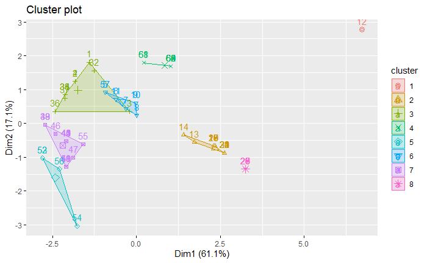

```r
fviz_cluster(k, data=scaled.df)
```

### Part 2.1(b)(iii)

```r
ob.per.cluster <-as.data.frame(table(k$cluster))
names(ob.per.cluster) <-c("Cluster","Observations")
print(ob.per.cluster)
```

| Cluster | Observations |
| --- | --- |
| 1 | 1 |
| 2 | 14 |
| 3 | 10 |
| 4 | 9 |
| 5 | 4 |
| 6 | 8 |
| 7 | 15 |
| 8 | 5 |

### Part 2.1(b)(iv)

```r
print(paste("Total SSE of the clusters is", signif(k$tot.withinss, 5),"."))
```

```
[1] "Total SSE of the clusters is 52.305 ."
```

### Part 2.1(b)(v)

```r
sse.cluster <-c()
for (x in 1:max(k$cluster)){
  sse.cluster <-rbind(sse.cluster,c(x,k$withinss[x]))
}
colnames(sse.cluster) <- c("Cluster", "SSE")
print(sse.cluster)
```

```
     Cluster          SSE
[1,]       1 0.000000e+00
[2,]       2 5.796663e+00
[3,]       3 1.858275e+01
[4,]       4 6.337449e+00
[5,]       5 6.226867e+00
[6,]       6 4.244696e+00
[7,]       7 1.111705e+01
[8,]       8 2.465190e-31
```

### Part 2.1(b)(vi)

```r
for (i in 1:8) {
  print(paste0("Group ", i, ": ", paste(unlist(file19.df[which(k$cluster==i),][1], use.names=FALSE), collapse=", ")))
}
```

```
[1] "Group 1: Armadillo"
[1] "Group 2: Pika, Snowshoe rabbit, Beaver, Marmot, Groundhog, Prairie Dog, Ground Squirrel, Chipmunk, Gray squirrel, Fox squirrel, Pocket gopher, Kangaroo rat, Porcupine, Guinea pig"
[1] "Group 3: Opossum, Hairy tail mole, Common mole, Star nose mole, Coyote, Wolf, Fox, Bear, Civet cat, Raccoon"
[1] "Group 4: Elk, Deer, Moose, Reindeer, Antelope, Bison, Mountain goat, Musk ox, Mountain sheep"
[1] "Group 5: Fur seal, Sea lion, Walrus, Elephant seal"
[1] "Group 6: Brown bat, Silver hair bat, Pigmy bat, House bat, Red bat, Hoary bat, Lump nose bat, Peccary"
[1] "Group 7: Marten, Fisher, Weasel, Mink, Ferrer, Wolverine, Badger, Skunk, River otter, Sea otter, Jaguar, Ocelot, Cougar, Lynx, Grey seal"
[1] "Group 8: Pack rat, Field mouse, Muskrat, Black rat, House mouse"
```

I believe that all the results meet my expectations. I expected that members of the animal kingdom like bats, squirrels, and rats are all clustered together in their own groups. Secondly, Group 4 contains animals that mostly make up livestock, if not entirely. The Other 7 groups include animals are either from entirely different classes, or similar classes. I don’t believe animals of similar/same class will be found in another group/cluster, unless the features significantly set them apart. In terms of SSE’s, the **Total SSE** is ~52.3, so it is not bad. The ratio **between_SS / total_SS** is close to 90% which is a pretty good number. Lastly, looking at the **within SSE** metric for each cluster indicates a good clustering performance overall.